# Composition Analysis of the Swedish National Library dated 2025-11-17

# Overall summary

66,210,882 records and 1,297,358,311 attribute values in total. Constituent files:

- data/kbse/kbse.parquet (4.06GB)- data/kbse/kbse_1.parquet (391MB)

## Temporal overview

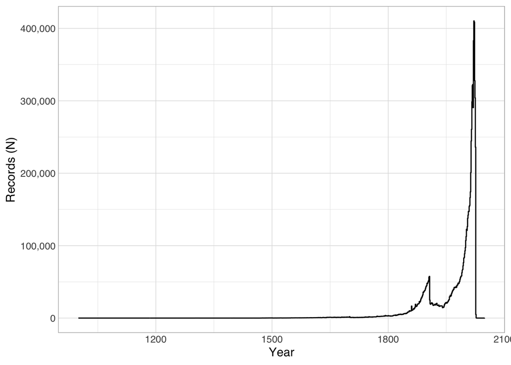

55,321,563 records do not have easily parseable dates between the years 1000 and 2050.

## Language overview

| [] | Records (N) | Proportion (%) |
| --- | --- | --- |
|  | 51914698 | 0.784046971505621 |
| swe (Swedish) | 4606443 | 0.0695692707980939 |
| und (Undetermined) | 4589841 | 0.0693185374157879 |
| eng (English) | 2897681 | 0.0437625200562542 |
|  | 441571 | 0.00666887063957703 |
| ger (German) | 413698 | 0.00624791584105781 |
| fre (French) | 224109 | 0.00338462881431292 |
| zxx (No linguistic content; Not applicable) | 164229 | 0.00248028506461497 |
| lat (Latin) | 132512 | 0.00200127586773504 |
| spa (Spanish; Castilian) | 91008 | 0.00137445751457099 |

[output cut: 447 more lines]

# Field code usage overview

In total, 385 distinct fields are used.

Legend for the table below:

- `records`: how many records have at least one of this field
- `r_p`: the above as a percentage of all records
- `n`: the total number of appearances of this field
- `vals_per_rec`: calculated from the above, the mean number of appearances of this field per record
- `recs_with_mult_vals`: the number of records that have more than one repetition of this field

| field_code | field_description | records | r_p | n | vals_per_rec | recs_with_mult_vals |
| --- | --- | --- | --- | --- | --- | --- |
| <a name="001">001</a> | NA | 66210881 | 0.999999984896742 | 66210881 | 1 | 0 |
| <a name="003">003</a> | NA | 7928508 | 0.119746297897074 | 7928509 | 1.00000012612714 | 1 |
| <a name="004">004</a> | NA | 29142240 | 0.440142754781608 | 29142240 | 1 | 0 |
| <a name="005">005</a> | NA | 66210881 | 0.999999984896742 | 66210881 | 1 | 0 |
| <a name="006">006</a> | NA | 72942 | 0.00110166180840183 | 98359 | 1.3484549367991 | 25397 |
| <a name="007">007</a> | NA | 9423494 | 0.142325456410624 | 9682567 | 1.02749224438409 | 259025 |
| <a name="008">008</a> | NA | 66210881 | 0.999999984896742 | 66213759 | 1.00004346717574 | 2878 |
| <a name="009">009</a> | NA | 1 | 1.5103257497763e-08 | 1 | 1 | 0 |
| <a name="010">010</a> | NA | 180490 | 0.00272598694577124 | 181538 | 1.00580641586792 | 986 |
| <a name="011">011</a> | NA | 2 | 3.0206514995526e-08 | 2 | 1 | 0 |

[output cut: 375 more lines]

# Field code usage overview by subfield

In total, 2,223 distinct field+subfield combinations are used.

Legend for the table below:

- `records`: how many records have at least one of this field+subfield
- `r_p`: the above as a percentage of all records
- `dist_vals`: the number of different values appearing in this field+subfield
- `e_vals`: at most seven random sample values of this field+subfield
- `n`: the total number of appearances of this field+subfield
- `vals_per_rec`: calculated from the above, the mean number of appearances of this field+subfield per record
- `recs_with_mult_vals`: the number of records that have more than one repetition of this field+subfield

| subfield_code | subfield_description | records | r_p | dist_vals | e_vals | n | vals_per_rec | recs_with_mult_vals |
| --- | --- | --- | --- | --- | --- | --- | --- | --- |
| 001: NA |  |  |  |  |  |  |  |  |
| 001$ | NA | 66,210,881 | 100% | 62,194,935 | 4j37ptpt26fm43cl (1)\|9ml1j4h67rckck2w (1)\|9v15lk8k73lwnqlv (1)\|47106303 (1)\|1640986 (1)\|vdm0jl4bsdwntrml (1)\|22780511 (1) | 66,210,881 | 1 | 0 |
| 003: NA |  |  |  |  |  |  |  |  |
| 003$ | NA | 7,928,508 | 11.97% | 87 | HSTalks (68)\|DE-603 (67)\|SpMaBN (260)\|se-libr (1)\|DE-B1597 (56)\|ES-GrU (1)\|CaToSAGE (1524) | 7,928,509 | 1 | 1 |
| 004: NA |  |  |  |  |  |  |  |  |
| 004$ | NA | 29,142,240 | 44.01% | 8,803,374 | 7811790 (1)\|9683423 (2)\|7733747 (1)\|11483689 (3)\|9434867 (1)\|361512 (2)\|9279137 (1) | 29,142,240 | 1 | 0 |
| 005: NA |  |  |  |  |  |  |  |  |
| 005$ | NA | 66,210,881 | 100% | 22,173,727 | 20091228133053.0 (1)\|20250304080030.0 (1)\|20210126200704.0 (1)\|20081208100824.0 (1)\|20090422153850.0 (1)\|20240119135124.0 (1)\|20141002122248.0 (1) | 66,210,881 | 1 | 0 |
| 006: NA |  |  |  |  |  |  |  |  |
| 006$ | NA | 72,942 | 0.11% | 427 | e\|\|\|\|\| e \|\| 0 \|\| (22)\|m o d i (15)\|abf\|\|\|\|\|\|\|\|\|000 0\| (2)\|eek\|\|\| a \|\| 0 \|\| (2)\|k\| \| \|\| a\| (1)\|a\|\|\|\|j\|\|\|\|\|\|000 0\| (11)\|m o h \| (12) | 98,359 | 1.35 | 25,397 |
| 007: NA |  |  |  |  |  |  |  |  |
| 007$ | NA | 9,423,494 | 14.23% | 575 | vf aaah\|\| (1)\|sd \|\|\|\|\|\|\|l\|\|\| (1)\|c\| \|\|a \|\|\|\|\| (3909)\|hd \|\|\|\| \|\|\|\| (11)\|sd \|\|\|\|\|\|\|\|\|\|\| (127251)\|kj bo\| (897)\|sd a\|\|glammhed (1) | 9,682,567 | 1.03 | 259,025 |
| 008: NA |  |  |  |  |  |  |  |  |
| 008$ | NA | 66,210,881 | 100% | 2,642,817 | 011211c19259999no ux p\|\|\|\|\|\|\|0 \|0nor\|d (1)\|191015s1999 sw \|\|\|\|\|\|\|\|\|\|\|000 \|\|swe\|c (1)\|080603s2008 sw \|\|\|\|\|\|\|\|\|\|\|000 f\|swe\| (4)\|140515s2011 sz a\|\|\|\|\|\|\|\|\|\… | 66,213,759 | 1 | 2,878 |
| 009: NA |  |  |  |  |  |  |  |  |
| 009$ | NA | 1 | 0% | 1 | $$a LB2822.75 (1) | 1 | 1 | 0 |
| 010: NA |  |  |  |  |  |  |  |  |
| 010$a | NA | 180,209 | 0.27% | 178,745 | 71024425 (1)\|2007036704 (1)\|2017018496 (1)\|2023020311 (1)\|2011009227 (1)\|2020944206 (1)\|2002011249 (1) | 180,963 | 1 | 727 |
| 010$z | NA | 539 | 0% | 573 | 2004001268 (1)\|86004675 (1)\|2015310847 (1)\|2014016083 (1)\|sc 91020113 (1)\|sn 97033661 (1)\|sn 86026119 (1) | 575 | 1.07 | 24 |
| 011: NA |  |  |  |  |  |  |  |  |
| 011$a | NA | 2 | 0% | 2 | BIB MATCHES WORLDCAT (1)\|a (1) | 2 | 1 | 0 |
| 012: NA |  |  |  |  |  |  |  |  |
| 012$a | NA | 2 | 0% | 2 | -3-7-1510160006-p----- (1)\|-3-7-1406050339-p----- (1) | 2 | 1 | 0 |
| 012$l | NA | 1 | 0% | 1 | a (1) | 1 | 1 | 0 |
| 014: NA |  |  |  |  |  |  |  |  |
| 014$Y | NA | 10,098,756 | 15.25% | 1 | 1 (10100405) | 10,100,405 | 1 | 1,649 |
| 014$a | NA | 10,098,756 | 15.25% | 3,833,537 | 9923023931 (1)\|9930964584 (1)\|0306413736 (1)\|992068211X (5)\|9905465278 (1)\|9908239538 (2)\|9907049743 (5) | 10,100,405 | 1 | 1,649 |
| 015: NA |  |  |  |  |  |  |  |  |
| 015$2 | NA | 100,022 | 0.15% | 36 | DE-600 (1)\|Bnb (1)\|GyFmDB (126)\|kktzm jnb (4)\|slb (8)\|bni (48)\|LAC (3) | 104,647 | 1.05 | 4,242 |
| 015$a | NA | 130,658 | 0.2% | 121,995 | GBA484680 (1)\|GBA8E1770 (1)\|GBA906502 (1)\|GBA906368 (1)\|GB89-41947 (1)\|01224893 (1)\|97,G01,0995 (1) | 137,682 | 1.05 | 6,437 |

[output cut: 2578 more lines]